# C1PythonNumPyIntrosj slides

#### Containers

- lists (mutable)

```
type([1,2,'abc'])  # prints "<class 'list'>"
```

- dictionaries

```
type({'cat': 'cute', 'dog': 'furry', 1:3}) # prints "<class 'dict'>"
```

- sets

  ```
  type({1,2,"a"})  # prints "<class 'set'>"
  ```

- tuples (immutable)

  ```
  type((1,2,"a"))  # prints "<class 'tuple'>"
  ```

###### Lists

```python
# List   - mutable type

xs = [3, 1, 2]    # Create a list
print(xs, xs[2])  # Prints "[3, 1, 2] 2"

print(xs[-1])
# Negative indices count from the end of the list; prints "2"

xs[2] = 'foo'
# Lists can contain elements of different types
print(xs)  # Prints "[3, 1, 'foo']"

xs.append('bar')
# Add a new element to the end of the list
print(xs) # Prints "[3, 1, 'foo', 'bar']"

x = xs.pop()
# Remove and return the last element of the list
print(x, xs)      # Prints "bar [3, 1, 'foo']"
```

```python
# slicing

nums = list(range(5))
# range is a built-in function that creates a list of integers
print(nums)               # Prints "[0, 1, 2, 3, 4]"

print(nums[2:4])
# Get a slice from index 2 to 4 (exclusive); prints "[2, 3]"

print(nums[2:])
# Get a slice from index 2 to the end; prints "[2, 3, 4]"

print(nums[:2])
# Get a slice from the start to index 2 (exclusive); prints "[0, 1]"

print(nums[:])
# Get a slice of the whole list; prints "[0, 1, 2, 3, 4]"

print(nums[:-1])
# Slice indices can be negative; prints "[0, 1, 2, 3]"

nums[2:4] = [8, 9]        # Assign a new sublist to a slice
print(nums)               # Prints "[0, 1, 8, 9, 4]"
```

```python
# loops in lists

animals = ['cat', 'dog', 'monkey']
for animal in animals:
    print(animal)
# Prints "cat", "dog", "monkey", each on its own line.
```

```
cat
dog
monkey
```

```python
# index within a loop

animals = ['cat', 'dog', 'monkey']
for idx, animal in enumerate(animals):
    print('#%d: %s' % (idx + 1, animal))
# Prints "#1: cat", "#2: dog", "#3: monkey", each on its own line
```

```
#1: cat
#2: dog
#3: monkey
```

```python
# list comprehension

nums = [0, 1, 2, 3, 4]
squares = [x ** 2 for x in nums]
print(squares)   # Prints [0, 1, 4, 9, 16]
nums = [0, 1, 2, 3, 4]
even_squares = [x ** 2 for x in nums if x % 2 == 0]
print(even_squares)  # Prints "[0, 4, 16]"
```

###### Dictionaries

* Dictionaries - store key-value pairs * no restriction on values * the keys must be immutable: numbers, string, tuples, but not lists * when duplicate keys are encountered, the last one wins

```python
d={'cat':1, 2:3, 'cat':'dog'}
print(d['cat']) #Prints "dog"

d = {'cat': 'cute', 'dog': 'furry', 1:3}
# Create a new dictionary with some data

print(d['cat'])       # Get an entry from a dictionary; prints "cute"
print('cat' in d)     # Check if a dictionary has a given key; prints "True"

d['fish'] = 'wet'     # Set an entry in a dictionary
print(d['fish'])      # Prints "wet"

# print(d['monkey'])  # KeyError: 'monkey' not a key of d

print(d.get('monkey', 'N/A'))  # Get an element with a default; prints "N/A"
print(d.get('fish', 'N/A'))    # Get an element with a default; prints "wet"

del d['fish']         # Remove an element from a dictionary
print(d.get('fish', 'N/A')) # "fish" is no longer a key; prints "N/A"
```

```python
# loops in dictionaries
d = {'person': 2, 'cat': 4, 'spider': 8}
for animal in d:
    legs = d[animal]
    print('A %s has %d legs' % (animal, legs))
# Prints "A person has 2 legs", "A cat has 4 legs", "A spider has 8 legs"
```

```
A person has 2 legs
A cat has 4 legs
A spider has 8 legs
```

```python
# use 'item' to access the keys and the corresponding values

d = {'person': 2, 'cat': 4, 'spider': 8}
for animal, legs in d.items():
    print('A %s has %d legs' % (animal, legs))
# Prints "A person has 2 legs", "A cat has 4 legs", "A spider has 8 legs"
```

```
A person has 2 legs
A cat has 4 legs
A spider has 8 legs
```

```python
# define dictionaries using comprehension

nums = [0, 1, 2, 3, 4]
even_num_to_square = {x: x ** 2 for x in nums if x % 2 == 0}
print(even_num_to_square)  # Prints "{0: 0, 2: 4, 4: 16}"
```

```
{0: 0, 2: 4, 4: 16}
```

###### Sets

* sets are unordered collections

```python
animals = {'cat', 'dog'}
print('cat' in animals)   # Check if an element is in a set; prints "True"
print('fish' in animals)  # prints "False"
animals.add('fish')       # Add an element to a set
print('fish' in animals)  # Prints "True"
print(len(animals))       # Number of elements in a set; prints "3"
animals.add('cat')        # Adding an element that is already in the set does nothing
print(len(animals))       # Prints "3"
animals.remove('cat')     # Remove an element from a set
print(len(animals))       # Prints "2"
```

```python
#loops  - no assumption about the order in which the elements are visited
animals = {'cat', 'dog', 'fish'}
for idx, animal in enumerate(animals):
    print('#%d: %s' % (idx + 1, animal))
# Prints "#1: fish", "#2: dog", "#3: cat"

# define sets using comprehension
from math import sqrt
nums = {int(sqrt(x)) for x in range(30)}
print(nums)  # Prints "{0, 1, 2, 3, 4, 5}"
```

###### Tuples

* the tuples are IMMUTABLE ordered list of values * similar to lists, but they can be used as keys in dictionaries

```python
d = {(x, x + 1): x for x in range(10)}
# Create a dictionary with tuple keys


t = (5, 6)        # Create a tuple
print(type(t))    # Prints "<class 'tuple'>"
print(d[t])       # Prints "5"
print(d[(1, 2)])  # Prints "1"
```

##### Functions

```python
def sign(x):
    if x > 0:
        return 'positive'
    elif x < 0:
        return 'negative'
    else:
        return 'zero'

for x in [-1, 0, 1]:
    print(sign(x))

# a function without explicit "return" returns the value "None"
```

```
negative
zero
positive
```

```python
# functions with default argument values

def hello(name, loud=False):
    if loud:
        print('HELLO, %s!' % name.upper())
    else:
        print('Hello, %s' % name)

hello('Bob') # Prints "Hello, Bob"
hello('Fred', loud=True)  # Prints "HELLO, FRED!"
```

```
Hello, Bob
HELLO, FRED!
```

##### Classes

```python
# classes
class Greeter(object):

    def __init__(self, name):   # Constructor
        self.name = name  # Create an instance variable

    def greet(self, loud=False):     # Instance method
        if loud:
            print('HELLO, %s!' % self.name.upper())
        else:
            print('Hello, %s' % self.name)

g = Greeter('Fred')  # Construct an instance of the Greeter class
g.greet()            # Call an instance method; prints "Hello, Fred"
g.greet(loud=True)   # Call an instance method; prints "HELLO, FRED!"
```

```
Hello, Fred
HELLO, FRED!
```

### Numpy

https://docs.scipy.org/doc/numpy/user/basics.html

- core library for scientific computing
- high-performance multidimensional array objects

A numpy array is a grid of values, all of the same type, indexed by a tuple of nonnegative integers.

The number of dimensions is the rank of the array; the shape of an array is a tuple of integers giving the size of the array along each dimension.

```python
# creation and properties

import numpy as np

nb = np.array([[1,2,3], [4,5,6], [7,8,9]])

type(nb)
# prints "<class 'numpy.ndarray'>"

# the number of array dimenstions
nb.ndim   # prints 2


#  the number of elements in each dimension
nb.shape # prints "(3, 3)"

# the type of elements
nb.dtype #prints "dtype('int32')"
```

```python
# we can access and change the elements using square brackets



a = np.array([1, 2, 3])   # Create a rank 1 array
print(type(a))            # Prints "<class 'numpy.ndarray'>"
print(a.shape)            # Prints "(3,)"
print(a[0], a[1], a[2])   # Prints "1 2 3"
a[0] = 5                  # Change an element of the array
print(a)                  # Prints "[5, 2, 3]"

b = np.array([[1,2,3],[4,5,6]])    # Create a rank 2 array
print(b.shape)                     # Prints "(2, 3)"
print(b[0, 0], b[0, 1], b[1, 0])   # Prints "1 2 4"
```

```python
# functions to create arrays

a = np.zeros((2,2))   # Create an array of all zeros
print(a)              # Prints "[[ 0.  0.]
                      #          [ 0.  0.]]"

b = np.ones((1,2))    # Create an array of all ones
print(b)              # Prints "[[ 1.  1.]]"

c = np.full((2,2), 7)  # Create a constant array
print(c)               # Prints "[[ 7.  7.]
                       #          [ 7.  7.]]"
```

```python
# more functions to create arrays


d = np.eye(2)         # Create a 2x2 identity matrix
print(d)              # Prints "[[ 1.  0.]
                      #          [ 0.  1.]]"


e = np.random.random((2,2))
# Create an array filled with random values
print(e)
```

```
[[1. 0.]
 [0. 1.]]
[[0.11331951 0.35187138]
 [0.10653637 0.27661838]]
```

```python
# slicing - a slice for each dimension


# Create the following rank 2 array with shape (3, 4)
# [[ 1  2  3  4]
#  [ 5  6  7  8]
#  [ 9 10 11 12]]
a = np.array([[1,2,3,4], [5,6,7,8], [9,10,11,12]])

# Use slicing to pull out the subarray consisting of the first 2 rows
# and columns 1 and 2; b is the following array of shape (2, 2):
# [[2 3]
#  [6 7]]
b = a[:2, 1:3]
```

```python
# IMPORTANT!
# A slice of an array is a view into the same data, so modifying it
# will modify the original array.


a = np.array([[1,2,3,4], [5,6,7,8], [9,10,11,12]])
b = a[:2, 1:3]
print(a[0, 1])   # Prints "2"
b[0, 0] = 77     # b[0, 0] is the same piece of data as a[0, 1]
print(a[0, 1])   # Prints "77"
```

```python
# indexing and slicing  - accessing rows


# Create the following rank 2 array with shape (3, 4)
# [[ 1  2  3  4]
#  [ 5  6  7  8]
#  [ 9 10 11 12]]
a = np.array([[1,2,3,4], [5,6,7,8], [9,10,11,12]])
print(a)
```

```
[[ 1  2  3  4]
 [ 5  6  7  8]
 [ 9 10 11 12]]
```

```python
# Two ways of accessing the data in the middle row of the array.
# Mixing integer indexing with slices yields an array of lower rank,
# while using only slices yields an array of the same rank as the
# original array:
row_r1 = a[1, :]    # Rank 1 view of the second row of a
row_r2 = a[1:2, :]  # Rank 2 view of the second row of a
print(row_r1, row_r1.shape)  # Prints "[5 6 7 8] (4,)"
print(row_r2, row_r2.shape)  # Prints "[[5 6 7 8]] (1, 4)"
```

```
[5 6 7 8] (4,)
[[5 6 7 8]] (1, 4)
```

```python
# indexing and slicing -accessing columns

# Two ways of accessing the data in the second column of the array.
# Mixing integer indexing with slices yields an array of lower rank,
# while using only slices yields an array of the same rank as the
# original array:


col_r1 = a[:, 1]
col_r2 = a[:, 1:2]
print(col_r1, col_r1.shape)  # Prints "[ 2  6 10] (3,)"
print(col_r2, col_r2.shape)
```

```
[ 2  6 10] (3,)
[[ 2]
 [ 6]
 [10]] (3, 1)
```

```python
# Integer indexing

a = np.array([[1,2], [3, 4], [5, 6]])

# An example of integer array indexing.
# The returned array will have shape (3,) and
print(a[[0, 1, 2], [0, 1, 0]])  # Prints "[1 4 5]"
# for each row we specify  which element is considered

# The above example of integer array indexing is equivalent to this:
print(np.array([a[0, 0], a[1, 1], a[2, 0]]))  # Prints "[1 4 5]"

# When using integer array indexing, you can reuse the same
# element from the source array:
print(a[[0, 0], [1, 1]])  # Prints "[2 2]"

# Equivalent to the previous integer array indexing example
print(np.array([a[0, 1], a[0, 1]]))  # Prints "[2 2]"
```

```python
# Create a new array from which we will select elements

a = np.array([[1,2,3], [4,5,6], [7,8,9], [10, 11, 12]])

print(a)
```

```
[[ 1  2  3]
 [ 4  5  6]
 [ 7  8  9]
 [10 11 12]]
```

```python
# Create an array of indices
b = np.array([0, 2, 0, 1])

# Select one element from each row of a using the indices in b
print(a[np.arange(4), b])  # Prints "[ 1  6  7 11]"

# Mutate one element from each row of a using the indices in b
a[np.arange(4), b] += 10

print(a)
```

```
[ 1  6  7 11]
[[11  2  3]
 [ 4  5 16]
 [17  8  9]
 [10 21 12]]
```

```python
# Boolean indexing - let you pick up arbitrary elements of an array

a = np.array([[1,2], [3, 4], [5, 6]])

bool_idx = (a > 2)   # Find the elements of a that are bigger than 2;
                     # this returns a numpy array of Booleans of the same
                     # shape as a, where each slot of bool_idx tells
                     # whether that element of a is > 2.

print(bool_idx)      # Prints "[[False False]
                     #          [ True  True]
                     #          [ True  True]]"
```

```
[[False False]
 [ True  True]
 [ True  True]]
```

```python
# We use boolean array indexing to construct a rank 1 array
# consisting of the elements of a corresponding to the True values
# of bool_idx

print(a[bool_idx])  # Prints "[3 4 5 6]"

# We can do all of the above in a single concise statement:

print(a[a > 2])     # Prints "[3 4 5 6]"
```

```
[3 4 5 6]
[3 4 5 6]
```

```python
# the elements of an array have the same type
# the type can be guessed

x = np.array([1, 2])   # Let numpy choose the datatype
print(x.dtype)         # Prints "int64"

x = np.array([1.0, 2.0])   # Let numpy choose the datatype
print(x.dtype)             # Prints "float64"

# or it can be forced

x = np.array([1, 2], dtype=np.int64)   # Force a particular datatype
print(x.dtype)                         # Prints "int64"
```

### Matplotlib

https://matplotlib.org/users/pyplot_tutorial.html

```python
# 2D plotting
import numpy as np
import matplotlib.pyplot as plt

def desen():
  x = np.arange(0, 3 * np.pi, 0.1)
  y_sin = np.sin(x)
  y_cos = np.cos(x)

  plt.plot(x, y_sin)
  plt.plot(x, y_cos)
  plt.xlabel('x axis label')
  plt.ylabel('y axis label')
  plt.title('Sine and Cosine')
  plt.legend(['Sine', 'Cosine'])
  plt.show()
```

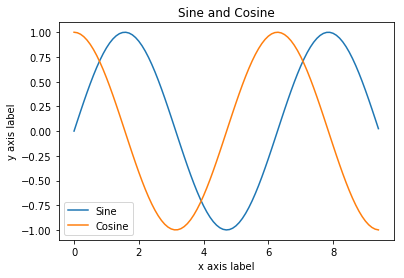

```python
desen()
```

## Next topic: pandas